# Mixed models – Examples

## Alternative approach

This data set can be reduced to remove multiple data points per participant by calculating each change score. Then we can use:

- Difference between groups in change scores in t-test
- Difference between groups in change scores using an ANCOVA with pre-values as a covariate.

```r
# Re-format the data set
str2 <- str %>%
  select(-time) %>% #removes the new time variable
  # Create a wide data set
  pivot_wider(names_from = timepoint,
              values_from = load) %>%
  rowwise() %>%
  # Rowwise calculation of means over two variables
  # to calculate the average at baseline
  mutate(pre_average = mean(c(pre, session1), na.rm = TRUE)) %>%
  ungroup() %>%
  # Calculate the change score
  mutate(change = post - pre_average) %>%
   print()
```

```
## # A tibble: 34 x 9
##    subject exercise sex    group      pre session1  post pre_average change
##    <chr>   <chr>    <chr>  <fct>    <dbl>    <dbl> <dbl>       <dbl>  <dbl>
##  1 FP11    isom     male   single    256.     252   281         254.   27.2
##  2 FP12    isom     female single    246.     290.  308         268.   40.5
##  3 FP13    isom     male   multiple  204      210.  294.        207.   87.2
##  4 FP14    isom     female single    197      184.  226         191.   35.2
##  5 FP15    isom     male   single    321      311   298.        316   -18.5
##  6 FP16    isom     female single    154.     195   248         175.   73.2
##  7 FP17    isom     male   multiple  314.     318   336.        316.   19.8
##  8 FP19    isom     male   single    238.     259   266         248.   17.8
##  9 FP2     isom     female multiple  138      152   216.        145    70.5
## 10 FP20    isom     female single    130.     142.  146.        136.   10
## # ... with 24 more rows
```

```r
# Alternativ 1: t-test
# A t-test can be performed on the change scores
t <- t.test(change ~ group, data = str2)
t
```

```
##
##  Welch Two Sample t-test
##
## data:  change by group
## t = -2.0271, df = 28.324, p-value = 0.05216
## alternative hypothesis: true difference in means is not equal to 0
## 95 percent confidence interval:
##  -36.2557690   0.1804014
## sample estimates:
##   mean in group single mean in group multiple
##               33.35294               51.39062
```

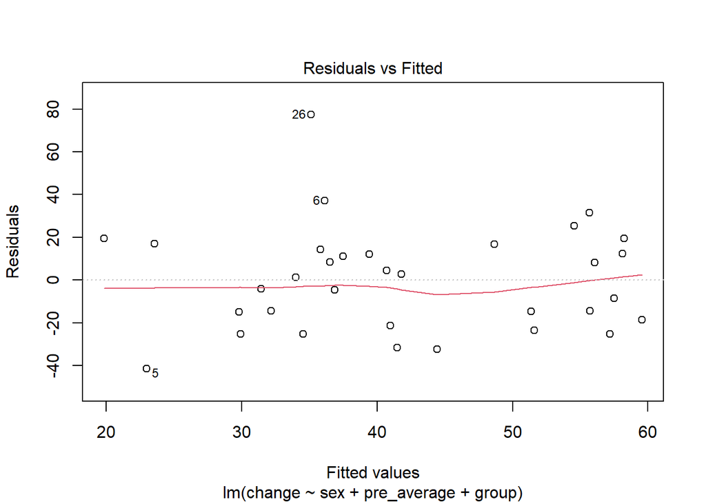

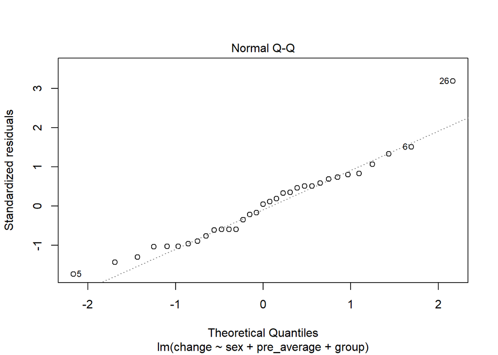

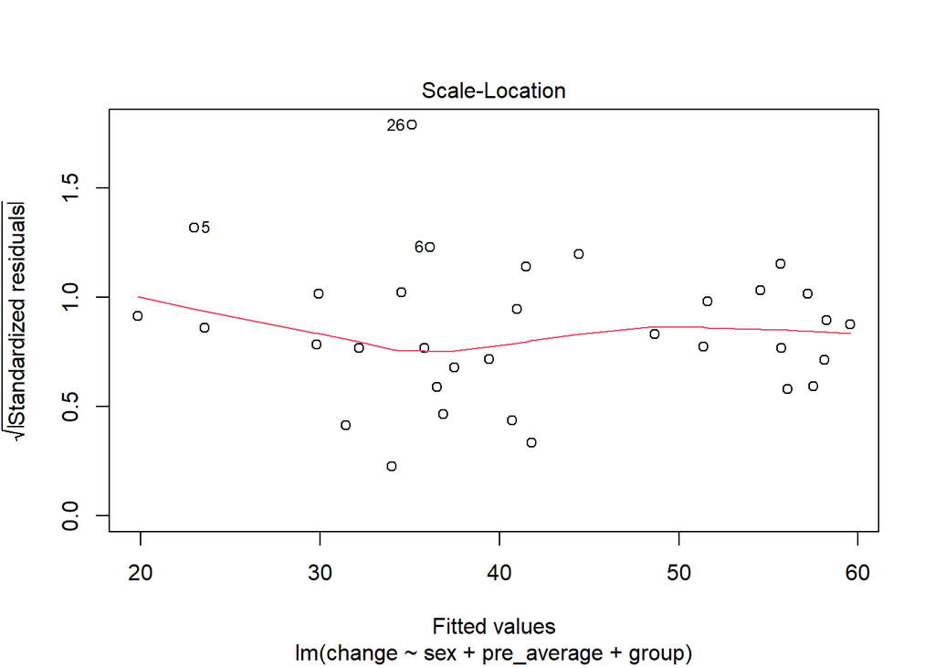

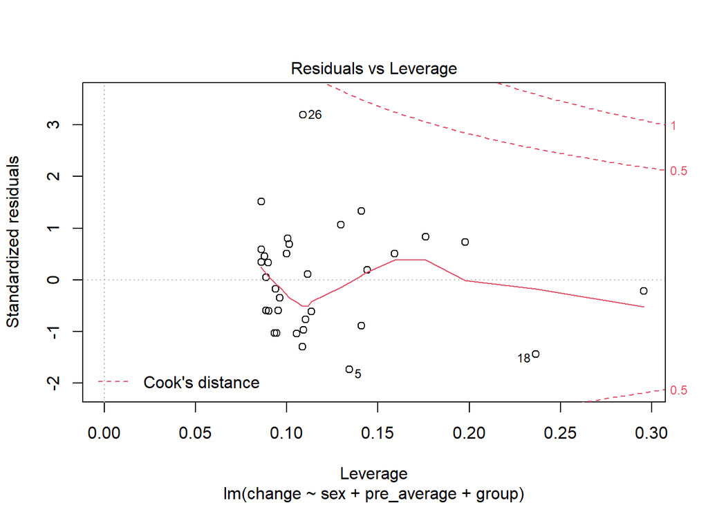

```r
# ANCOVA
# the ANCOVA canm controll for the expected relationship between
# the baseline and change values... (regression to the mean)
# We might have to take care of sex diferences, adding sex to the
# model will accomplish this
m2 <- lm(change ~ sex + pre_average + group, data = str2)

# The ancova model can be checked with ordinary assumption checks
plot(m2)
```

```r
# The results can be plotted
summary(m2)
```

```
##
## Call:
## lm(formula = change ~ sex + pre_average + group, data = str2)
##
## Residuals:
##     Min      1Q  Median      3Q     Max
## -41.482 -18.551   1.274  14.444  77.387
##
## Coefficients:
##               Estimate Std. Error t value Pr(>|t|)
## (Intercept)   59.83059   18.25450   3.278  0.00272 **
## sexmale        5.98212   11.99282   0.499  0.62168
## pre_average   -0.13554    0.09428  -1.438  0.16124
## groupmultiple 17.95071    8.94336   2.007  0.05413 .
## ---
## Signif. codes:  0 '***' 0.001 '**' 0.01 '*' 0.05 '.' 0.1 ' ' 1
##
## Residual standard error: 25.66 on 29 degrees of freedom
##   (1 observation deleted due to missingness)
## Multiple R-squared:  0.1833, Adjusted R-squared:  0.0988
## F-statistic: 2.169 on 3 and 29 DF,  p-value: 0.1131
```

# Appendix R-code

In your reports (for the mappeeksamen) you should keep the report clean from code and printouts (remove all print() from your code). Instead use `eval = FALSE, echo = TRUE` with a copy of the code in the end of the report as an appendix.

```r
# Load the data
library(tidyverse)

strength <- read_csv("./data/strengthTests.csv")

# Filter the data

strength %>%
  filter(exercise == "isom") %>%
  mutate(timepoint = factor(timepoint))
  print()
```

# References

Cumming, Geoff. 2012. *Understanding the New Statistics : Effect Sizes, Confidence Intervals, and Meta-Analysis*. Book. Multivariate Applications Series. New York: Routledge.